正の安全余裕を持つ最も軽量なアルミニウム管は、2 - .049 である。長さ 10 in. の重量は $.3003 \times .101 \times 10 = .303\text{ lbs.}$ となる。  
最も軽量な鋼管は 1-1/4 - .035 であり、その重量は $0.1336 \times .283 \times 10 = .378\text{ lbs.}$ である。  
鋼管は $F_{tu} = 200,000$ に熱処理されているが、それでもアルミニウム合金管より重い。

# 丸管の複合荷重下における強度

複合荷重下における構造部材の極限強度を決定する際に使用される応力比および相互作用式の一般的な説明については、セクション C1 の第 C1.15 項を参照されたい。

## C4.22 曲げと圧縮の複合荷重

曲げと圧縮の複合荷重を受ける管において、圧縮による応力は断面全体にわたって均一であるが、曲げ応力は断面全体にわたって均一ではない。以下の応力比方程式は多少保守的である可能性があるが、文献1で推奨されている。

$$R_c + R_b' = 1$$

これは以下のように書くことができる。

$$\frac{f_c}{F_c} + \frac{f_b'}{F_b} = 1.0$$

ここで、 $f_b'$ は、軸荷重による2次モーメントと梁のたわみを考慮した最大曲げ応力に等しい。

$$F_b = \text{曲げ破壊係数応力}$$
$$f_c = \text{圧縮柱軸応力}$$
$$F_c = \text{許容柱応力}$$

式(C4.12)は次のようにも記述できる。

$$\frac{P}{P_a} + \frac{M}{M_a} = 1.0$$

ここで、
$$P = \text{柱荷重}$$
$$P_a = \text{破損時の許容柱荷重}$$
$$M = \text{曲げモーメント}$$
$$M_a = \text{許容極限曲げモーメント}$$

図 C4.32 は式(C4.11)のグラフを示している。

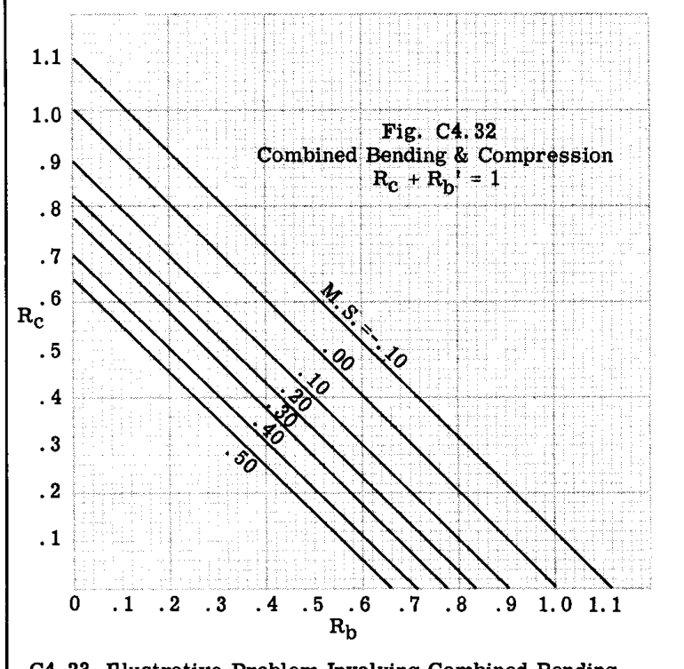

Fig. C4.32

安全余裕の式は次の通りである。

$$M.S. = \frac{1}{R_c + R_b'} - 1$$

図 C4.32 は、式(C4.14)を使用しない場合に、M.S. の値を詳細に見積もるための安全余裕曲線を示している。

### C4.23 曲げと圧縮の複合荷重に関する例題

図 C4.33 は、梁-柱として機能する丸管 2024-T3 を示している。これはピン A および点 C における傾斜支柱 BC によって支持されている。 $10\text{ lb./in.}$ の均一な横方向荷重を受ける場合の安全余裕を求めることが要求されている。

管 AC の軸荷重を求めるために、点 (B) のまわりのモーメントをとる。

$$\sum M_B = -40 \times 10 \times 20 + 20 R_{AH} = 0$$

したがって、
$$R_{AH} = 400\text{ lb.}$$

したがって、管の軸荷重は $400\text{ lb.}$ の圧縮である。

長さ 40 インチ、端部固定度 $C = 1$ の 2024-T3 1-1/4 - .049 丸管の柱強度は、図 C4.6 から得られ、 $-2100\text{ lb.}$ に等しい。したがって、応力比は次のようになる。

$$R_c = \frac{\text{柱荷重}}{\text{柱強度}} = \frac{-400}{-2100} = .191$$

荷重の対称性から、曲げモーメントはスパンの中央で最大になり、モーメントの値は、たわみによる2次モーメントを含む以下の式から得られる。（第 A5 章の表 A5.1 を参照）

$$M_{\text{max}} = w j^2 \left(1 - \sec \frac{L}{2j}\right)$$

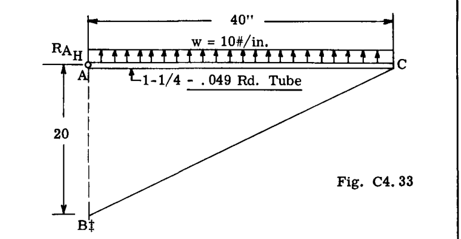

Fig. C4.33

$$w j^2 = 10 \times 860 = 8600$$

$$\frac{L}{2j} = \frac{40}{58.6} = .683$$

$$\sec \frac{L}{2j} = \frac{1}{\cos \frac{L}{2j}}$$

第 A5 章の表 A5.2 より、 $.683$ のコサインは $.7757$ である。

したがって、
$$\frac{1}{\cos L/2j} = 1 / .7757 = 1.29$$

式(A)に代入すると、

$$M_{\text{max}} = 8600 (1 - 1.29) = -2490\text{ in. lb.}$$

$D/t = 25.5$ に対する図 C4.12 から、 $F_b/F_{tu} = 1.03$ を読み取る。したがって、 $F_b = 1.03 \times 62000 = 64000\text{ psi}$ である。次に、 $M = F_b I/y = 64000 \times .0534 = 3420\text{ in. lbs.}$ である。

曲げの応力比 $R_b = \frac{2490}{3420} = .728$

$R_c + R_b = .191 + .728 = .917$ となり、これは部材が脆弱ではないことを示している。

安全余裕 $M.S. = \left(\frac{1}{R_c + R_b}\right) - 1 = \left(\frac{1}{.191 + .728}\right) - 1 = .09$

安全余裕は、図 C4.32 の曲線から直接読み取ることもできる。

最大曲げモーメント $2490\text{ in. lb.}$ は、1次モーメントである $w L^2 / 8 = 10 \times 40^2 / 8 = 2000$ よりも 24 パーセント大きいことに注意されたい。したがって、管の中点における横方向のたわみは $490 / 400 = 1.22\text{ インチ}$ に等しい。

横方向のたわみによる2次モーメントは線形に変化しないため、設計荷重が増加した場合は、モーメントが梁に加えられた荷重に直接比例して増加すると仮定するのではなく、最大曲げの計算を繰り返す必要がある。

### C4.23a 曲げと引張の複合荷重

広く使用されている丸管の曲げと引張の複合荷重に対する相互作用式は、次の通りである。

$$R_b + R_t^{1.5} = 1$$

この式は図 C4.34 にプロットされている。応力比は $R_t = f_t / F_{tu}$ である。この図は $D/t = 10$ に基づいており、一般的に他の $D/t$ 比に対して保守的である。

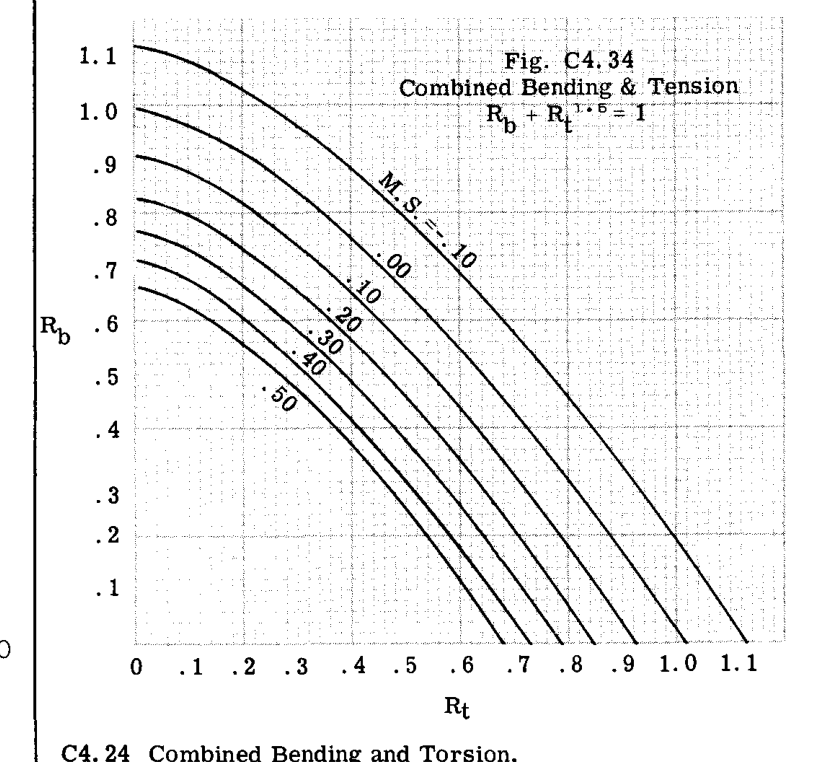

Fig. C4.34

## C4.24 曲げとねじりの複合荷重

文献1による曲げとねじりの複合荷重の相互作用式は、次の通りである。

$$R_b^2 + R_{st}^2 = 1$$

この式は、 $M.S. = 0$ について図 C4.35 にプロットされている。様々な $M.S.$ 値を示す曲線も同図に示されている。

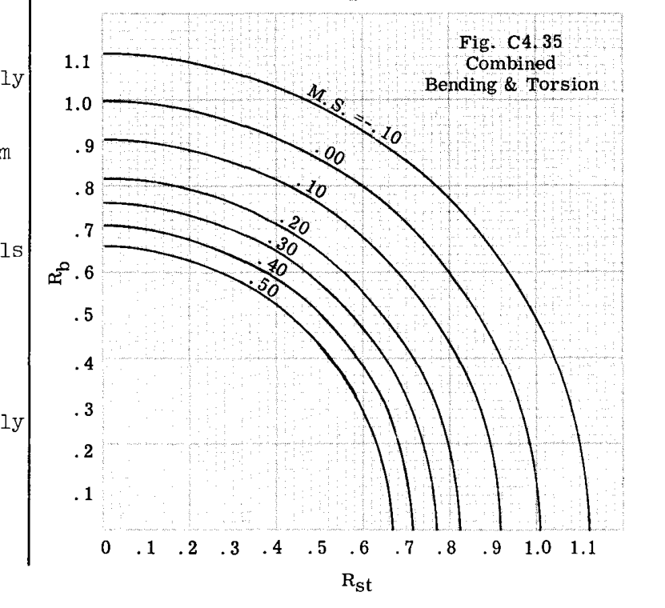

Fig. C4.35

安全余裕の式は、次の通りである。

$$M.S. = \frac{1}{\sqrt{R_b^2 + R_{st}^2}} - 1$$

### 例題 1

$1-1/2 - .058$ の丸鋼管（ $F_{tu} = 125000$ ）の長さは 30 インチである。これに $10,000\text{ in. lbs.}$ の極限設計曲げモーメントと $6000\text{ in. lbs.}$ のねじりモーメントが作用している。安全余裕を求めよ。

**解法:**  
$D/t = 25.85$ , $I/y = .0912$ , $L/D = 20$

$F_b$ を求めるために、図 C4.11 を参照すると、 $D/t = 25.85$ および $F_{tu} = 125000$ に対して $F_b = 148000$ と読み取れる。したがって、 $M_a = F_b I/y = 148000 \times .0912 = 13500\text{ in. lb.}$ である。

次に、
$$R_b = \frac{M}{M_a} = \frac{10000}{13500} = .74$$

$F_{st}$ を求めるために、図 C4.18 を参照すると、 $D/t = 25.85$ および $L/D = 20$ に対して $F_{st}/1000$ が 61 であるため、 $F_{st} = 61000$ と読み取れる。

$$R_{st} = \frac{T}{T_a} = \frac{6000}{11120} = .54$$

$$M.S. = \frac{1}{\sqrt{R_b^2 + R_{st}^2}} - 1 = \frac{1}{\sqrt{.74^2 +
.54^2}} - 1 = \frac{1}{.917} - 1 = .09$$

したがって、この管の極限強度は、複合荷重下で 9 パーセントの安全余裕を持っている。

試行錯誤プロセスを伴う設計問題において、複合曲げおよびねじり荷重によって生じるものと同じねじり応力を生じさせる等価ねじりモーメント $T_e$ を使用することは、試行錯誤プロセスを短縮する上で非常に有用である。

$$f_{s(\text{max})} = \frac{T_e r}{2I}$$

$$f_{s(\text{max})} = \sqrt{f_s^2 + (f_b / 2)^2}$$

また、 $f_s = T r / 2I$ 、および $f_b = M r / I$ である。

これらの値を C4.18 に代入すると、

$$f_{s(\text{max})} = \frac{r}{2I} \left[ M \sqrt{1 + (T/M)^2} \right]$$

C4.20 と C4.18 を等置して $T_e$ について解くと、

$$T_e = M \sqrt{1 + (T/M)^2}$$

$T_e$ の値が決まれば、C4.21 の問題2と同様に、このねじりモーメント $T_e$ を発生させる管のサイズを選択する。これらのサイズは、上記の例題で説明したように、曲げとねじりの複合荷重に対してチェックされる。

### C4.24a 圧縮、曲げ、ねじりの複合荷重における極限強度

文献1による圧縮、曲げ、ねじりの複合荷重に対する相互作用式は次の通りである。

$$R_b^2 + R_{st}^2 = (1 - R_c)^2$$

図 C4.36 および 37 は、この式のグラフを示している。安全余裕の式は次の通りである。

$$M.S. = \frac{1}{R_c + \sqrt{R_b^2 + R_{st}^2}} - 1$$

相互作用曲線の使用方法を説明するために、3つの応力比に対して以下の値を仮定する。

$$R_c = .333,\quad R_b = .20,\quad R_{st} = .20$$

このとき、
$$\frac{R_{st}}{R_c} = \frac{.20}{.333} = .60$$

図 C4.36 において、 $R_c = .333$ と $R_b = .20$ の交点に点 (a) を配置する。交点 (a) は $R_{st}/R_c = .60$ 曲線の内側にあるため、正の安全余裕が存在することがわかる。ここで、(0) と (a) を通る直線を惹き、それを延長して点 (b) で $R_{st}/R_c = .60$ 曲線と交差させる。これを $R_c$ 軸に垂直に投影すると、 $R_c = .538$ と読み取れる。したがって、 $M.S. = (.538 / .333) - 1 = .62$ となる。

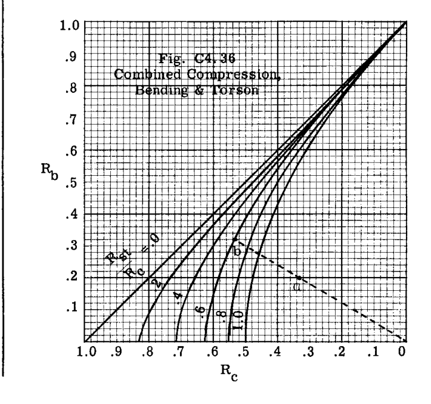

Fig. C4.36

点 (b) から $R_b$ 軸に水平に投影すると、 $R_b = .323$ と読み取れる。したがって、 $M.S. = (.323 / .200) - 1 = .62$ となり、先に求めた値と一致する。 $R_{st}/R_c$ の比が 1 より大きい場合は、図 C4.37 の曲線を使用し、比 $R_c / R_{st}$ を使用する。

式(C4.23)に代入すると、

$$M.S. = \frac{1}{.333 + \sqrt{.20^2 + .20^2}} - 1 = .62$$

となり、曲線から得られた値と一致する。

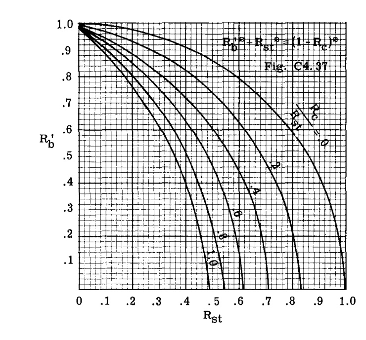

Fig. C4.37

### 例題

図 C4.38 に示す極限設計荷重を受ける 2024-T3 アルミニウム合金製の $1-1/8 - .049$ 丸管がある。この複合荷重下における安全余裕を求めよ。

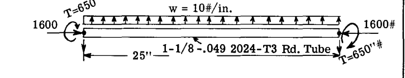

Fig. C4.38

**解法:**  
対称性から、最大曲げモーメントは管の中央で発生する。端部モーメントを持たない均一な側方荷重を受ける梁-柱について、最大モーメントは以下の式で与えられる（第 A5 章、表 A5.1 を参照）。

$$M_{\text{max}} = w j^2 \left(1 - \sec \frac{L}{2j}\right)$$

$$j = \sqrt{\frac{EI}{P}} = \sqrt{\frac{10,300,000 \times .0240}{1600}} =
\sqrt{154.7} = 12.43$$

$$\frac{L}{2j} = \frac{25}{2 \times 12.43} = \frac{25}{24.86} = 1.005$$

$$\sec \frac{L}{2j} = \frac{1}{\cos L/2j} = \frac{1}{.5361} = 1.87\text{
（表 A5.2 を参照）}$$

したがって、

$$M_{\text{max}} = 10 \times 154.7 (1 - 1.87) = -1347\text{ in. lb.}$$

長さ 25 インチ、端部固定度 $c = 1$ の柱強度は、図 C4.6 から読み取ることができ、 $3700\text{ lb.}$ に等しい。したがって、 $R_c = P / P_a = 1600 / 3700 = .432$ である。

極限曲げ強度を求めるために、図 C4.12 を参照する。ここで $D/t = 1.125 / .049 = 22.95$ に対して $F_b / F_{tu} = 1.04$ と読み取れる。したがって、 $F_b = 1.04 \times 62000 = 64500$ である。これにより $M_a = F_b I/y = 64500 \times .0427 = 2760\text{ in. lb.}$ となる。

したがって、 $R_b = \frac{1347}{2760} = .487$ である。

極限ねじり強度を求めるために、図 C4.26 を参照する。ここで $D/t = 22.95$ 、および $L/D = 25 / 1.125 = 22.2$ の位置を見積もると、 $F_{st} = 27500$ と読み取れる。

このとき、
$$T_a = F_{st} J/r = 27500 \times .0427 \times 2 = 2350$$

したがって、
$$R_{st} = \frac{T}{T_a} = \frac{650}{2350} = .276$$

$$M.S. = \frac{1}{R_c + \sqrt{R_b^2 + R_{st}^2}} - 1$$

$$= \frac{1}{.432 + \sqrt{.487^2 + .276^2}} - 1 = \frac{1}{.992} - 1 = .01$$

## C4.25 曲げと曲げせん断の複合荷重における極限強度

文献2によるこのタイプの複合荷重からの相互作用曲線は次の通りである。

$$R_b^2 + R_s^2 = 1$$

$$M.S. = \frac{1}{\sqrt{R_b^2 + R_s^2}} - 1$$

許容曲げせん断応力または横せん断応力は、管の許容ねじり応力（ $F_{st}$ ）の 1.2 倍として扱われる。

### 例題

$1-1/4 - .058$ の丸アルミニウム合金 2024-T3 管が単純梁として使用され、図 C4.39 に示すように $600\text{ lb.}$ の極限設計荷重を支持している。

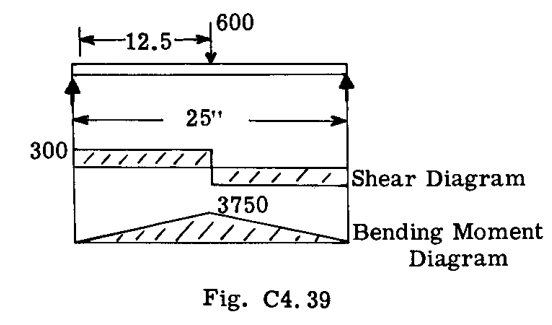

Fig. C4.39

危険断面は、せん断力と曲げ力が最大となる梁の中点に隣接している。

許容せん断応力 $F_s$ は $1.2 F_{st}$ とすることができる（文献2）。

$F_{st}$ を求めるために、図 C4.26 を参照する。ここで $D/t = 21.6$ および $L/D = 20$ に対して $F_{st} = 28400$ と読み取れる。したがって、 $F_s = 1.2 \times 28400 = 34000$ である。

丸管内の最大せん断応力は、中心線軸で発生し、以下の式で与えられる。

$$f_s = \frac{4}{3} \frac{V}{A} \left(1 + \frac{d D}{d^2 + D^2}\right)$$

ここで、
$$V = \text{垂直梁せん断荷重}$$
$$A = \text{管断面積}$$
$$D = \text{外径}$$
$$d = \text{内径}$$

近似式は、以下の通りである。

$$f_s = 2 \frac{V}{A}$$

$D/t > 10$ の場合、誤差は 1% 未満である。

近似式を用いると、

$$f_s = \frac{2 \times 300}{.2172} = 2760\text{ psi}$$

$$R_s = \frac{f_s}{F_s} = \frac{2760}{34000} = .081$$

$$M.S. = \frac{1}{\sqrt{R_b^2 + R_s^2}} - 1 = \frac{1}{\sqrt{.915^2 +
.081^2}} - 1 = .09$$

せん断応力の影響は 1 パーセント未満である。 $F_s = 1.2 F_{st}$ を使用する場合、その結果が材料の $F_{su}$ より大きいときは、 $F_s$ として $F_{su}$ を使用する。

## C4.26 圧縮、曲げ、曲げせん断、ねじりの複合荷重における極限強度

文献2に提示されているこの複合荷重に対する相互作用式は、次の通りである。

$$R_c + R_{st} + \sqrt{R_b^2 + R_s^2} = 1$$

この式の相互作用曲線は図 C4.40 に示されている。ここで、曲げせん断の応力比 $R_s$ は前の項目で説明したように求めることができる。

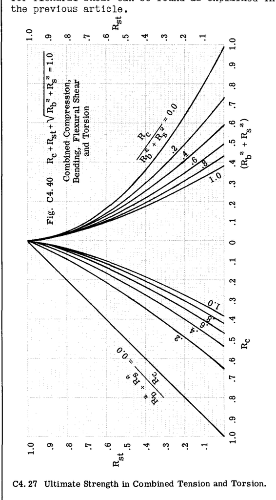

Fig. C4.40

## C4.27 引張とねじりの複合荷重における極限強度

文献3に提示されているこのタイプの荷重に対する相互作用式は、次の通りである。

$$R_t^2 + R_{st}^2 = 1$$

ここで、 $R_t = f_t / F_{tu}$ である。

$$M.S. = \frac{1}{\sqrt{R_t^2 + R_{st}^2}} - 1$$

## C4.28 引張、ねじり、および内圧 $p$ (psi) の複合荷重における極限強度

文献3は、以下の相互作用式を与えている。

$$R_t^2 + R_{st}^2 + R_p^2 = 1$$

ここで、 $R_p = p / p_{\text{max}}$ であり、 $p_{\text{max}} = \frac{2 t F_{tu}}{d}$ である。

ここで、 $t = \text{肉厚}$ 、 $d = \text{管径}$ である。

安全余裕の式は次の通りである。

$$M.S. = \frac{1}{\sqrt{R_t^2 + R_{st}^2 + R_p^2}} - 1$$

# 問題

1. 図 1 は小型飛行機の鋼管製胴体の一部を示している。各トラス部材に隣接して、臨界引張および圧縮荷重が示されている。すべての部材について端部固定度係数 $c = 2$ と仮定し、トラスのすべての部材について管のサイズを選択せよ。使用する最小サイズは $3/4 - .035$ とする。上部および下部のロンジロンは、入れ子式のサイズを使用して少なくとも1回はスプライス（継手）する必要がある。材料は合金鋼 $F_{tu} = 95000$ であり、トラスは溶接されている。

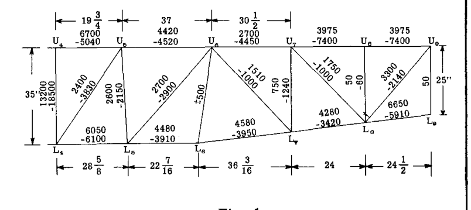

Fig. 1

2. 図 2 の片持ち溶接鋼管トラスについて、図に示すトラス荷重に対して最も軽量な部材を選択せよ。

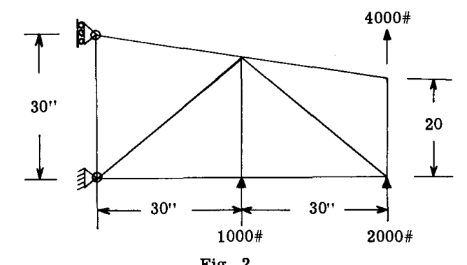

Fig. 2

上部および下部のロンジロンは連続部材でなければならない。最小サイズは $3/4 - .035$ とする。ウェブ部材には $C = 2$ 、ロンジロンには $C = 1.5$ を使用せよ。材料はクロムモリブデン鋼 $F_{tu} = 95000\text{ psi}$ である。

3. 図 2 のトラスが溶接後に $180000\text{ psi}$ に熱処理される場合、問題(2)で得られた結果に対してどれだけの重量を節約できるか。
4. 問題(2)と同じであるが、材料を 2024-T3 アルミニウム合金丸管に変更する。部材はリベットとガセットプレートで結合される。引張部材の設計において、リベットまたはボルト穴によって管面積の 10% が切り取られると仮定せよ。
5. 図 3 は、代表的な管状エンジンマウント構造を示している。エンジンは点 A および B で支持されている。設計の目的上、エンジントルクは A で 60%、B で 40% 反応されると仮定する。管材料は鋼 $F_{tu} = 95000\text{ psi}$ である。すべての部材に $C = 1$ を使用せよ。以下の設計条件に対して管のサイズを決定せよ。
- 条件 I：
  - 垂直荷重係数 = 10（下向き）
  - 推力荷重係数 = 2（前向き）
  - エンジントルク荷重係数 = 2
- 条件 II：
  - 垂直荷重係数が 5（上向き）であることを除いて条件 I と同じ。
- 一般データ：
  - パワープラント設置重量 = $440\text{ lb.}$
  - 最大エンジン推力 = $400\text{ lb.}$
  - エンジン H.P. = 2000 R.P.M. で 120

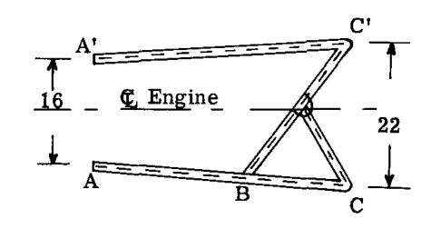

Fig. 3

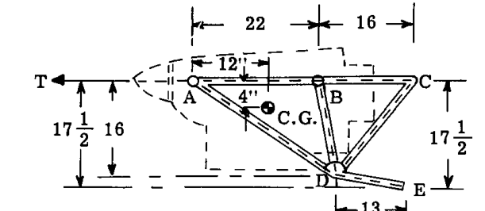

Fig. 4

6. 図 4 に示す荷重は、左側の支持部に伝達される必要がある。言い換えれば、片持ち構造である。

問題は、合金鋼 $F_{tu} = 95000$ の丸管を使用し、トラスジョイント部で溶接された最も軽量なトラス構成を設計することである。すべての部材の端部固定度には $C = 1.5$ を使用せよ。トラスのタイプや部材の配置に制限はないが、目標は最も軽量なトラスにすることである。トラスジョイント部のガセットプレートの重量は考慮に入れなくてよい。

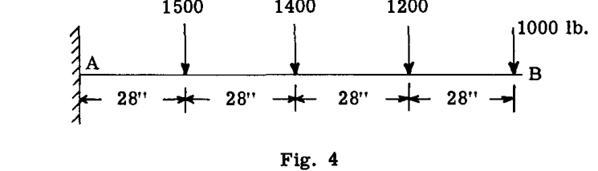

Fig. 4

7. 問題(6)と同じであるが、片持ちトラスの代わりに、点 (A) と (B) に支持部を持つ単純支持トラスを使用する。
8. 図 5 は、外部支持された単葉機の前部梁と前部リフト支柱を示している。翼梁とリフト支柱は同じ垂直面内にある。致命的な条件における梁の極限設計荷重は $w = 50\text{ lb./in.}$ および $w = -30\text{ lbs./in.}$ である。マイナスは荷重が下向きに作用していることを意味する。
- 1. リフト支柱として機能する流線形管を設計せよ。材料は 2024-T3 アルミニウム合金である。
- 2. (a)と同じであるが、合金鋼 $F_{ty} = 75000$ で作られている。2つの設計の重量を比較せよ。

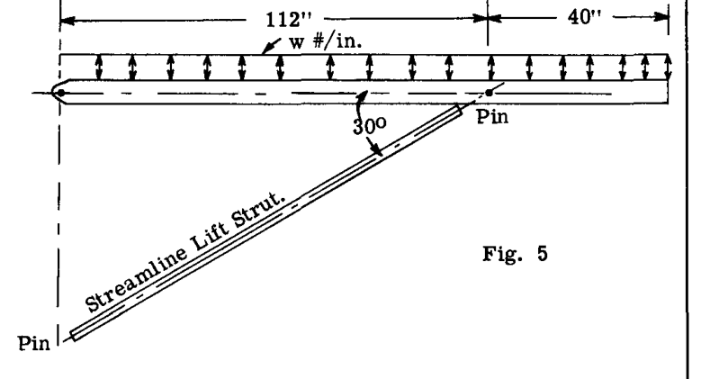

Fig. 5

9. 図 6 は、水上飛行機の胴体にフロートを取り付けるための支柱とワイヤブレースを示している。以下の荷重条件に対して、流線形支柱 AC および BD に必要なサイズを決定せよ。
- 条件 1:
  - $V = -32000\text{ lbs.}$
  - $H = -8000\text{ lbs.}$
- 条件 2:
  - $V = -8000\text{ lbs.}$
  - $H = -28000\text{ lbs.}$

材料は 2024-T3 アルミニウム合金である。 $C = 1$ を使用せよ。

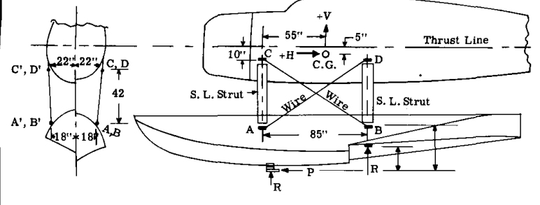

Fig. 6

10. 管サイズ $2 - .065$ 丸管。 $L = 44\text{ in.}$ 、 $C = 1.5$ 。材料は合金鋼 $F_{tu} = 95000$ 、端部溶接。極限設計荷重が $22000\text{ lb.}$ の圧縮および $28000\text{ lbs.}$ の引張に等しいとして設計せよ。安全余裕を求めよ。
11. 問題 10 と同じであるが、溶接後に $F_{tu} = 150000$ に熱処理されている。
12. 極限設計荷重が $20,000\text{ lbs.}$ の圧縮である。 $L = 30\text{ in.}$ 。 $C = 1$ を使用せよ。以下の材料から最も軽量な丸管を設計し、それらの重量を比較せよ。
- 1. アルミニウム合金 2024-T3
- 2. 合金鋼 $F_{tu} = 180,000$
- 3. マグネシウム合金 $F_{cy} = 10,000$
13. 問題(10)と同じ設計荷重であるが、2024-T3 アルミニウム合金材料から最も軽量な流線形管を設計せよ。
14. 丸管は $14000\text{ in. lbs.}$ の極限純曲げモーメントを伝達する必要がある。以下の材料から最も軽量な管サイズを選択し、それらの重量を比較せよ。
- 1. 合金鋼 $F_{tu} = 240,000$
- 2. 2024-T3 アルミニウム合金
- 3. マグネシウム合金 $F_{cy} = 30000$
- 4. チタン 6AL-4V 合金
15. 長さ 20 インチの丸管が $15000\text{ in. lb.}$ の極限ねじりモーメントを伝達する必要がある。以下の材料から最も軽量な管サイズを選択し、それらの重量を比較せよ。
- 1. 合金鋼 $F_{tu} = 180,000$
- 2. アルミニウム合金 2024-T3
- 3. マグネシウム合金 $F_{tu} = 36000$
16. $4500$ および $3000\text{ in.lbs.}$ の曲げとねじりの複合設計荷重をそれぞれ伝達するための、最も軽量な 2024-T3 アルミニウム合金製丸管（長さ 10 インチ）を決定せよ。
17. 問題 16 と同じであるが、材料を合金鋼 $F_{tu} = 95000$ に変更する。
18. $1-1/2 - .065$ の 2024-T3 丸管（長さ 50 インチ）が梁-柱として使用されている。梁上の分布荷重は 1 インチあたり $12\text{ lb.}$ であり、軸荷重は $700\text{ lbs.}$ である。これらの荷重における M.S. はいくらか。
19. もし問題(18)の管が $1400\text{ in.lb.}$ のねじりモーメントも受ける場合、M.S. はいくらになるか。

## 参考文献

1. Military Handbook. MIL-HDBK-5. March, 1961.
2. Lockheed Report 2072.
3. M. A. Sadowsky, “A Principle of Maximum Plastic Resistance,” Journal of Applied Mechanics, June, 1943.